# Analyse Économique et Développement Humain en Afrique de l’Ouest

KONGO Johan

2026-05-09

# 1 Introduction

Cette analyse porte sur les indicateurs économiques et de développement humain de six pays d’Afrique de l’Ouest : **Burkina Faso, Côte d’Ivoire, Ghana, Mali, Nigeria et Sénégal**. Elle examine l’évolution du PIB, de l’espérance de vie, du taux d’alphabétisation et de l’IDH sur la période 2010–2023, en cherchant à comprendre les relations entre croissance économique et bien-être des populations.

# 2 Aperçu des données

```r
data <- read.csv("economie_afrique_ouest.csv")
data$pays <- as.factor(data$pays)
```

```r
head(data)
```

```
##   annee    pays pib_milliards_usd pib_par_habitant_usd taux_croissance_pib
## 1  2010 Senegal              12.8                  982                 4.2
## 2  2011 Senegal              14.0                 1045                 2.1
## 3  2012 Senegal              14.5                 1058                 4.4
## 4  2013 Senegal              15.0                 1068                 2.8
## 5  2014 Senegal              15.6                 1088                 4.1
## 6  2015 Senegal              17.9                 1220                 6.4
##   inflation taux_chomage population_millions   idu esperance_vie
## 1       1.2         14.8                13.0 0.452          62.8
## 2       3.4         13.9                13.4 0.462          63.1
## 3       1.4         14.2                13.7 0.471          63.5
## 4       0.7         13.5                14.1 0.478          63.9
## 5      -1.1         13.8                14.4 0.485          64.3
## 6       0.1         13.5                14.7 0.492          64.8
##   taux_alphabetisation exportations_milliards importations_milliards
```

[output cut: 27 more lines]

```r
summary(data)
```

```
##      annee                pays    pib_milliards_usd pib_par_habitant_usd
##  Min.   :2010   Burkina_Faso:14   Min.   :  8.40    Min.   : 510.0
##  1st Qu.:2013   Cote_Ivoire :14   1st Qu.: 15.53    1st Qu.: 926.2
##  Median :2016   Ghana       :14   Median : 27.45    Median :1419.0
##  Mean   :2016   Mali        :14   Mean   : 98.54    Mean   :1465.9
##  3rd Qu.:2020   Nigeria     :14   3rd Qu.: 67.67    3rd Qu.:1986.0
##  Max.   :2023   Senegal     :14   Max.   :568.50    Max.   :3123.0
##
##  taux_croissance_pib   inflation       taux_chomage   population_millions
##  Min.   :-4.400      Min.   :-3.200   Min.   : 4.00   Min.   : 13.00
##  1st Qu.: 3.175      1st Qu.: 0.975   1st Qu.: 5.50   1st Qu.: 17.25
##  Median : 5.350      Median : 2.950   Median : 8.65   Median : 21.55
##  Mean   : 4.943      Mean   : 6.077   Mean   :10.37   Mean   : 50.40
##  3rd Qu.: 6.825      3rd Qu.: 9.925   3rd Qu.:13.82   3rd Qu.: 31.90
##  Max.   :14.000      Max.   :31.900   Max.   :22.00   Max.   :223.80
##
##       idu         esperance_vie   taux_alphabetisation exportations_milliards
##  Min.   :0.3300   Min.   :29.80   Min.   :25.00        Min.   : 1.50
##  1st Qu.:0.3977   1st Qu.:57.20   1st Qu.:33.42        1st Qu.: 3.20
##  Median :0.4860   Median :60.00   Median :50.25        Median : 6.55
##  Mean   :0.4695   Mean   :56.73   Mean   :47.93        Mean   :17.33
##  3rd Qu.:0.5195   3rd Qu.:64.22   3rd Qu.:55.62        3rd Qu.:14.68
##  Max.   :0.6180   Max.   :68.60   Max.   :73.70        Max.   :97.80
##
##  importations_milliards investissement_etranger dette_publique_pct_pib
##  Min.   : 2.20          Min.   :0.100           Min.   :13.80
##  1st Qu.: 4.20          1st Qu.:0.475           1st Qu.:28.00
##  Median : 7.95          Median :0.700           Median :34.25
##  Mean   :14.86          Mean   :1.560           Mean   :33.56
##  3rd Qu.:15.57          3rd Qu.:2.500           3rd Qu.:39.58
##  Max.   :62.80          Max.   :8.900           Max.   :47.80
##
##  secteur_agricole_pct secteur_industrie_pct secteur_services_pct
##  Min.   :20.50        Min.   :21.20         Min.   :21.00
##  1st Qu.:25.00        1st Qu.:27.75         1st Qu.:47.38
##  Median :27.50        Median :39.00         Median :51.50
##  Mean   :27.05        Mean   :37.38         Mean   :53.88
##  3rd Qu.:29.27        3rd Qu.:44.62         3rd Qu.:73.00
##  Max.   :33.00        Max.   :56.40         Max.   :80.20
##
##  taux_pauvrete   acces_electricite_pct acces_eau_potable_pct
##  Min.   :17.50   Min.   :50.00         Min.   :55.20
##  1st Qu.:33.02   1st Qu.:60.00         1st Qu.:61.50
##  Median :46.65   Median :63.65         Median :72.50
##  Mean   :48.03   Mean   :64.35         Mean   :69.62
##  3rd Qu.:58.05   3rd Qu.:69.00         3rd Qu.:77.60
##  Max.   :87.20   Max.   :79.00         Max.   :83.00
##                                        NAs    :57
```

> **Interprétation :** Le jeu de données contient 84 observations (6 pays × 14 années : 2010–2023). Le PIB varie de 8,4 à 568,5 milliards USD, avec une forte dispersion due au Nigeria. L’IDH moyen est de 0,47, ce qui place la région dans la catégorie « développement humain faible à moyen » selon le PNUD.

# 3 Analyse du PIB

## 3.1 Statistiques descriptives

```r
pib_stats <- data %>%
  group_by(pays) %>%
  summarise(
    moyenne_pib = round(mean(pib_milliards_usd, na.rm = TRUE), 2),
    mediane_pib = round(median(pib_milliards_usd, na.rm = TRUE), 2),
    sd_pib      = round(sd(pib_milliards_usd, na.rm = TRUE), 2)
  )

kable(pib_stats, caption = "Statistiques descriptives du PIB (milliards USD) par pays",
      col.names = c("Pays", "Moyenne", "Médiane", "Écart-type"))
```

Statistiques descriptives du PIB (milliards USD) par pays

| Pays | Moyenne | Médiane | Écart-type |
| --- | --- | --- | --- |
| Burkina_Faso | 14.16 | 13.10 | 3.86 |
| Cote_Ivoire | 46.61 | 41.75 | 17.94 |
| Ghana | 55.76 | 53.40 | 16.81 |
| Mali | 15.14 | 14.70 | 3.34 |
| Nigeria | 438.96 | 436.55 | 58.56 |
| Senegal | 20.59 | 20.25 | 5.87 |

> **Interprétation :** Le Nigeria domine très largement avec un PIB moyen de **438,96 milliards USD**, soit environ 8 fois celui du Ghana (55,76 Mds) et 30 fois celui du Burkina Faso (14,16 Mds). L’écart-type élevé du Nigeria (58,56) traduit une forte volatilité de son économie, très dépendante des cours pétroliers. Le Ghana et la Côte d’Ivoire occupent une position intermédiaire, tandis que le Burkina Faso, le Mali et le Sénégal affichent les PIB les plus modestes.

## 3.2 Distribution du PIB par pays

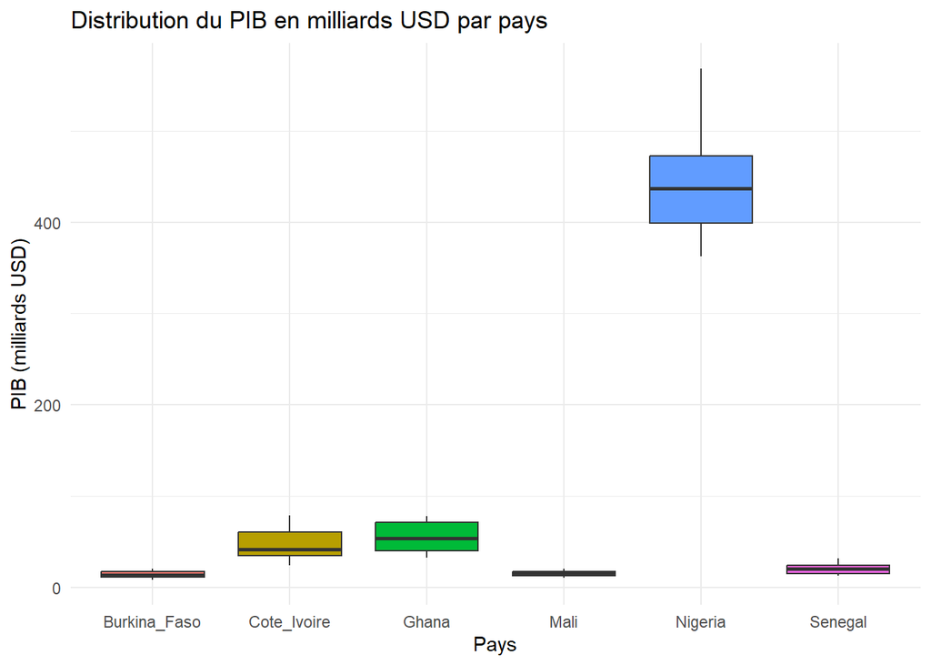

```r
ggplot(data, aes(x = pays, y = pib_milliards_usd, fill = pays)) +
  geom_boxplot() +
  labs(title = "Distribution du PIB en milliards USD par pays",
       x = "Pays",
       y = "PIB (milliards USD)") +
  theme_minimal() +
  theme(legend.position = "none")
```

## 3.3 Évolution temporelle du PIB

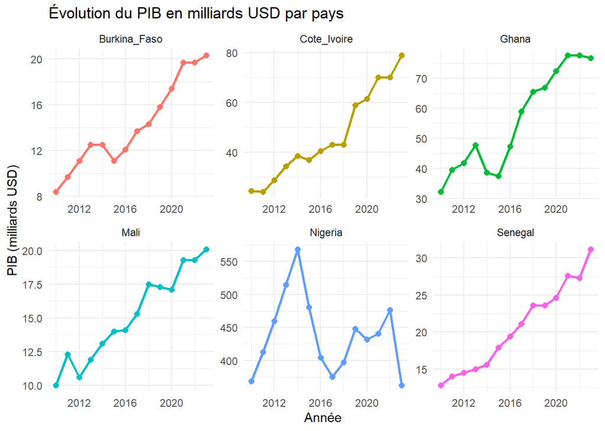

```r
ggplot(data, aes(x = annee, y = pib_milliards_usd, color = pays)) +
  geom_line(size = 1) +
  geom_point(size = 2) +
  facet_wrap(~ pays, scales = "free") +
  labs(
    title = "Évolution du PIB en milliards USD par pays",
    x = "Année",
    y = "PIB (milliards USD)",
    color = "Pays"
  ) +
  theme_minimal() +
  theme(legend.position = "none")
```

# 4 Espérance de Vie

## 4.1 Statistiques descriptives

```r
esperance_vie_stats <- data %>%
  group_by(pays) %>%
  summarise(
    moyenne_esperance_vie = round(mean(esperance_vie, na.rm = TRUE), 1),
    mediane_esperance_vie = round(median(esperance_vie, na.rm = TRUE), 1),
    sd_esperance_vie      = round(sd(esperance_vie, na.rm = TRUE), 2),
    max_esperance_vie     = round(max(esperance_vie, na.rm = TRUE), 1),
    min_esperance_vie     = round(min(esperance_vie, na.rm = TRUE), 1)
  )

kable(esperance_vie_stats, caption = "Statistiques de l'espérance de vie par pays (années)",
      col.names = c("Pays", "Moyenne", "Médiane", "Écart-type", "Maximum", "Minimum"))
```

Statistiques de l’espérance de vie par pays (années)

| Pays | Moyenne | Médiane | Écart-type | Maximum | Minimum |
| --- | --- | --- | --- | --- | --- |
| Burkina_Faso | 59.8 | 59.8 | 1.67 | 62.4 | 57.2 |
| Cote_Ivoire | 59.1 | 59.0 | 1.46 | 61.5 | 57.1 |
| Ghana | 66.0 | 66.0 | 1.66 | 68.6 | 63.5 |
| Mali | 31.8 | 31.8 | 1.25 | 33.7 | 29.8 |
| Nigeria | 58.2 | 58.2 | 1.67 | 60.8 | 55.6 |
| Senegal | 65.5 | 65.4 | 1.83 | 68.3 | 62.8 |

> **Interprétation :** Le Ghana (66,0 ans) et le Sénégal (65,5 ans) affichent les meilleures espérances de vie de la région. Le Mali se distingue de façon alarmante avec une espérance de vie moyenne de seulement **31,8 ans**, une valeur qui traduit des conditions sanitaires et sociales extrêmement précaires (conflits armés, sous-nutrition, accès limité aux soins). La Côte d’Ivoire (59,1 ans), le Burkina Faso (59,8 ans) et le Nigeria (58,2 ans) se situent dans une fourchette intermédiaire.

## 4.2 Proportion moyenne / maximum

```r
proportion_esperance_vie_stats <- esperance_vie_stats %>%
  mutate(proportion_esperance_vie = round(moyenne_esperance_vie / max_esperance_vie, 3))

kable(
  proportion_esperance_vie_stats %>%
    select(pays, moyenne_esperance_vie, max_esperance_vie, proportion_esperance_vie),
  caption = "Proportion espérance de vie moyenne / maximum par pays",
  col.names = c("Pays", "Moyenne", "Maximum", "Proportion")
)
```

Proportion espérance de vie moyenne / maximum par pays

| Pays | Moyenne | Maximum | Proportion |
| --- | --- | --- | --- |
| Burkina_Faso | 59.8 | 62.4 | 0.958 |
| Cote_Ivoire | 59.1 | 61.5 | 0.961 |
| Ghana | 66.0 | 68.6 | 0.962 |
| Mali | 31.8 | 33.7 | 0.944 |
| Nigeria | 58.2 | 60.8 | 0.957 |
| Senegal | 65.5 | 68.3 | 0.959 |

> **Interprétation :** Les proportions sont comprises entre **0,944 et 0,962** pour tous les pays, ce qui signifie que l’espérance de vie moyenne est très proche du maximum observé sur la période. Cela indique une amélioration lente mais régulière de la longévité, sans rupture majeure. Les pays n’ont pas réussi à combler significativement leur retard en santé publique sur la période analysée.

## 4.3 Distribution

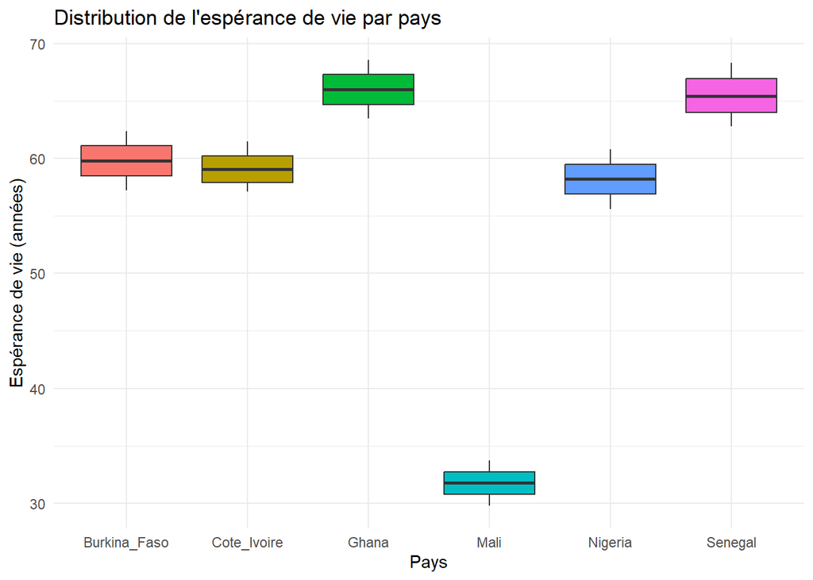

```r
ggplot(data, aes(x = pays, y = esperance_vie, fill = pays)) +
  geom_boxplot() +
  labs(title = "Distribution de l'espérance de vie par pays",
       x = "Pays",
       y = "Espérance de vie (années)") +
  theme_minimal() +
  theme(legend.position = "none")
```

# 5 Taux d’Alphabétisation

```r
taux_alphabetisation_stats <- data %>%
  group_by(pays) %>%
  summarise(
    moyenne_taux_alphabetisation = round(mean(taux_alphabetisation, na.rm = TRUE), 1),
    mediane_taux_alphabetisation = round(median(taux_alphabetisation, na.rm = TRUE), 1),
    sd_taux_alphabetisation      = round(sd(taux_alphabetisation, na.rm = TRUE), 2),
    max_taux_alphabetisation     = max(taux_alphabetisation, na.rm = TRUE),
    min_taux_alphabetisation     = min(taux_alphabetisation, na.rm = TRUE)
  )

kable(taux_alphabetisation_stats,
      caption = "Statistiques du taux d'alphabétisation par pays (%)",
      col.names = c("Pays", "Moyenne", "Médiane", "Écart-type", "Maximum", "Minimum"))
```

Statistiques du taux d’alphabétisation par pays (%)

| Pays | Moyenne | Médiane | Écart-type | Maximum | Minimum |
| --- | --- | --- | --- | --- | --- |
| Burkina_Faso | 33.2 | 33.2 | 2.80 | 37.4 | 28.7 |
| Cote_Ivoire | 47.2 | 47.2 | 2.10 | 50.5 | 43.9 |
| Ghana | 70.5 | 70.4 | 2.07 | 73.7 | 67.3 |
| Mali | 28.7 | 28.8 | 2.15 | 32.0 | 25.0 |
| Nigeria | 54.3 | 54.2 | 2.06 | 57.5 | 51.1 |
| Senegal | 53.7 | 53.8 | 2.17 | 57.0 | 50.0 |

# 6 Indice de Revenu (méthode PNUD)

```r
indice_revenu <- data %>%
  group_by(pays) %>%
  summarise(
    moyenne_pib          = round(mean(pib_milliards_usd, na.rm = TRUE), 2),
    moyenne_pib_habitant = round(mean(pib_par_habitant_usd, na.rm = TRUE), 0),
    indice_revenu        = round(
      (log(mean(pib_par_habitant_usd, na.rm = TRUE)) - log(100)) /
      (log(75000) - log(100)), 3
    )
  )

kable(indice_revenu,
      caption = "Indice de revenu par habitant (bornes PNUD : 100–75 000 USD)",
      col.names = c("Pays", "PIB moyen (Mds USD)", "PIB/hab moyen (USD)", "Indice de revenu"))
```

Indice de revenu par habitant (bornes PNUD : 100–75 000 USD)

| Pays | PIB moyen (Mds USD) | PIB/hab moyen (USD) | Indice de revenu |
| --- | --- | --- | --- |
| Burkina_Faso | 14.16 | 729 | 0.300 |
| Cote_Ivoire | 46.61 | 1859 | 0.441 |
| Ghana | 55.76 | 1707 | 0.429 |
| Mali | 15.14 | 853 | 0.324 |
| Nigeria | 438.96 | 2314 | 0.475 |
| Senegal | 20.59 | 1333 | 0.391 |

> **Interprétation :** Aucun pays de la région n’atteint un indice de revenu supérieur à **0,475** (Nigeria). Le Burkina Faso (0,300) et le Mali (0,324) présentent les indices les plus faibles, reflétant des PIB/habitant très bas (respectivement 729 et 853 USD). Ces chiffres confirment que l’ensemble de la région se situe dans la tranche « développement économique faible » selon les standards du PNUD, qui fixe le revenu maximum de référence à 75 000 USD/habitant.

# 7 Relation IDH et PIB par habitant

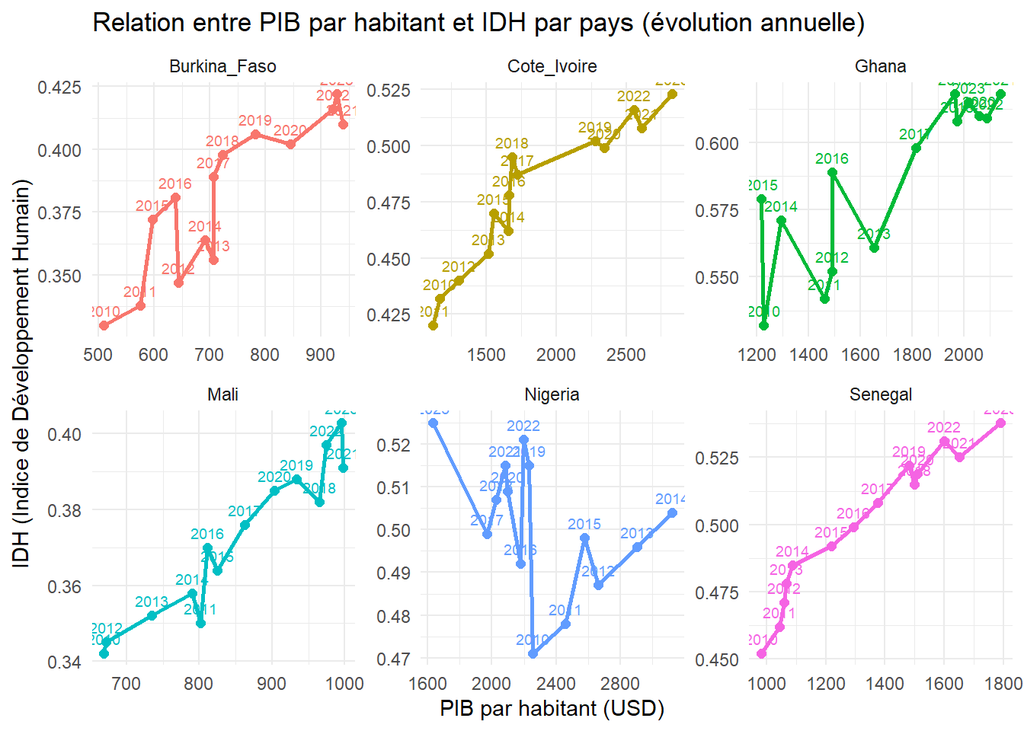

```r
ggplot(data, aes(x = pib_par_habitant_usd, y = idu, color = pays)) +
  geom_line(size = 1) +
  geom_point(size = 2) +
  geom_text(aes(label = annee), vjust = -0.8, size = 2.5) +
  facet_wrap(~ pays, scales = "free") +
  labs(
    title = "Relation entre PIB par habitant et IDH par pays (évolution annuelle)",
    x = "PIB par habitant (USD)",
    y = "IDH (Indice de Développement Humain)",
    color = "Pays"
  ) +
  theme_minimal() +
  theme(legend.position = "none")
```

# 8 Tests de Normalité (Shapiro-Wilk)

```r
shapiro.test(data$pib_milliards_usd)
```

```
##
##  Shapiro-Wilk normality test
##
## data:  data$pib_milliards_usd
## W = 0.57663, p-value = 3.419e-14
```

```r
shapiro.test(data$esperance_vie)
```

```
##
##  Shapiro-Wilk normality test
##
## data:  data$esperance_vie
## W = 0.72555, p-value = 3.106e-11
```

```r
shapiro.test(data$taux_alphabetisation)
```

```
##
##  Shapiro-Wilk normality test
##
## data:  data$taux_alphabetisation
## W = 0.93052, p-value = 0.0002154
```

```r
shapiro.test(data$idu)
```

```
##
##  Shapiro-Wilk normality test
##
## data:  data$idu
## W = 0.95672, p-value = 0.006562
```

**Récapitulatif des résultats :**

| Variable | W | p-value | Normalité |
| --- | --- | --- | --- |
| PIB (milliards USD) | 0.5766 | < 0.001 | ❌ Non normale |
| Espérance de vie | 0.7256 | < 0.001 | ❌ Non normale |
| Taux d’alphabétisation | 0.9305 | 0.0002 | ❌ Non normale |
| IDH | 0.9567 | 0.0066 | ❌ Non normale |

> **Interprétation :** Le test de Shapiro-Wilk rejette l’hypothèse de normalité pour **toutes les variables** (p < 0,05 dans tous les cas). Le PIB et l’espérance de vie ont des statistiques W très basses (0,58 et 0,73), signe de distributions très asymétriques dues aux valeurs extrêmes du Nigeria et du Mali. Ce résultat **justifie pleinement l’utilisation du test non paramétrique de Kruskal-Wallis** pour comparer les distributions entre pays.

## 8.1 QQ Plots

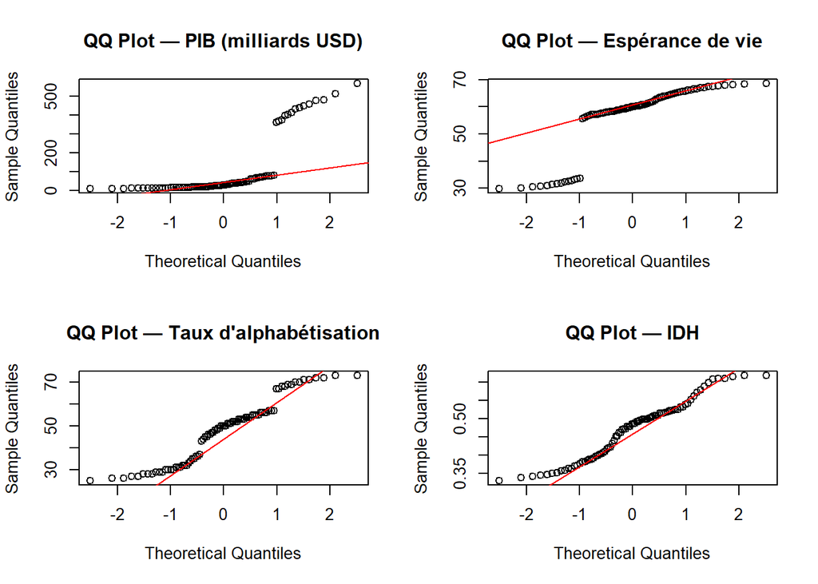

```r
par(mfrow = c(2, 2))
qqnorm(data$pib_milliards_usd, main = "QQ Plot — PIB (milliards USD)")
qqline(data$pib_milliards_usd, col = "red")

qqnorm(data$esperance_vie, main = "QQ Plot — Espérance de vie")
qqline(data$esperance_vie, col = "red")

qqnorm(data$taux_alphabetisation, main = "QQ Plot — Taux d'alphabétisation")
qqline(data$taux_alphabetisation, col = "red")

qqnorm(data$idu, main = "QQ Plot — IDH")
qqline(data$idu, col = "red")
```

```r
par(mfrow = c(1, 1))
```

> **Interprétation :** Les QQ Plots confirment visuellement les résultats de Shapiro-Wilk. Les points s’écartent nettement de la droite théorique pour le PIB et l’espérance de vie (queues lourdes et asymétrie). L’IDH et le taux d’alphabétisation se rapprochent davantage de la droite mais présentent encore des déviations significatives aux extrémités.

# 9 Analyses de Corrélation

## 9.1 PIB total et IDH

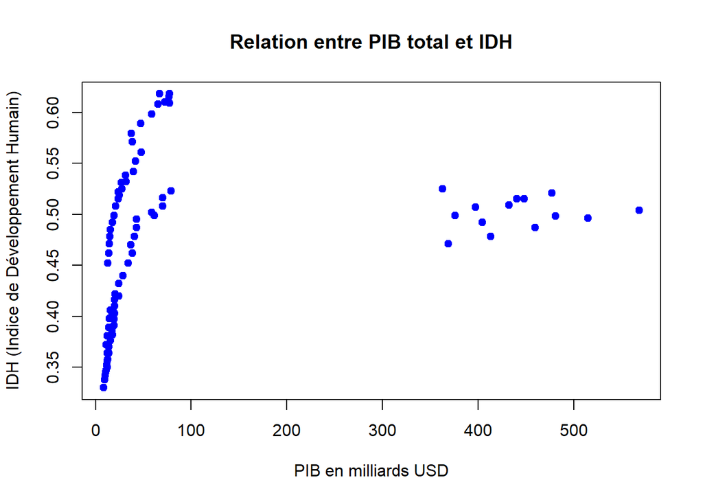

```r
plot(data$pib_milliards_usd, data$idu,
     main = "Relation entre PIB total et IDH",
     xlab = "PIB en milliards USD",
     ylab = "IDH (Indice de Développement Humain)",
     pch = 19, col = "blue")
```

```r
cortest <- cor.test(data$pib_milliards_usd, data$idu, method = "pearson")
print(cortest)
```

```
##
##  Pearson's product-moment correlation
##
## data:  data$pib_milliards_usd and data$idu
## t = 2.5838, df = 82, p-value = 0.01154
## alternative hypothesis: true correlation is not equal to 0
## 95 percent confidence interval:
##  0.06373882 0.46162383
## sample estimates:
##       cor
## 0.2743845
```

> **Interprétation :** La corrélation entre PIB total et IDH est **positive mais faible** (r = **0,274**, p = 0,012). Bien que statistiquement significative, cette faible corrélation s’explique par le fait que le PIB total est fortement influencé par la taille démographique du pays : le Nigeria a le PIB le plus élevé mais pas l’IDH le plus fort. **Le PIB agrégé est donc un indicateur trompeur du bien-être humain.**

## 9.2 PIB par habitant et IDH

```r
cor.test(data$pib_par_habitant_usd, data$idu)
```

```
##
##  Pearson's product-moment correlation
##
## data:  data$pib_par_habitant_usd and data$idu
## t = 8.8471, df = 82, p-value = 1.45e-13
## alternative hypothesis: true correlation is not equal to 0
## 95 percent confidence interval:
##  0.5698095 0.7942308
## sample estimates:
##       cor
## 0.6988322
```

> **Interprétation :** La corrélation entre PIB **par habitant** et IDH est nettement plus forte (r = **0,699**, p < 0,001). Ce résultat confirme que c’est le revenu **individuel** — et non la richesse nationale brute — qui détermine le niveau de développement humain. Un pays peut avoir un PIB total élevé mais un IDH faible si la population est très nombreuse ou si les richesses sont très inégalement distribuées.

## 9.3 Inflation et IDH

```r
cor.test(data$inflation, data$idu)
```

```
##
##  Pearson's product-moment correlation
##
## data:  data$inflation and data$idu
## t = 6.5494, df = 82, p-value = 4.726e-09
## alternative hypothesis: true correlation is not equal to 0
## 95 percent confidence interval:
##  0.4250526 0.7110925
## sample estimates:
##       cor
## 0.5860422
```

> **Interprétation :** On observe une corrélation **positive et significative** entre inflation et IDH (r = **0,586**, p < 0,001). Ce résultat contre-intuitif s’explique par le contexte des données : les pays ayant connu les IDH les plus élevés sur la période (Ghana, Sénégal) ont aussi traversé des phases de croissance économique nominale soutenue, accompagnées d’une inflation modérée. Il ne faut pas en conclure que l’inflation améliore le développement humain ; cette corrélation reflète plutôt une co-évolution dans un contexte de dynamisme économique. Une forte inflation, comme observée au Nigeria (jusqu’à 31,9%), reste néfaste.

## 9.4 Investissements étrangers et IDH

```r
cor.test(data$investissement_etranger, data$idu)
```

```
##
##  Pearson's product-moment correlation
##
## data:  data$investissement_etranger and data$idu
## t = 5.7735, df = 82, p-value = 1.341e-07
## alternative hypothesis: true correlation is not equal to 0
## 95 percent confidence interval:
##  0.3653132 0.6742806
## sample estimates:
##       cor
## 0.5376026
```

> **Interprétation :** La corrélation entre investissements directs étrangers (IDE) et IDH est **positive et significative** (r = **0,538**, p < 0,001). Les IDE contribuent au développement humain via la création d’emplois, le transfert de technologies et le financement d’infrastructures. Cependant, cette relation n’est pas automatique : des IDE concentrés dans les secteurs extractifs (pétrole, mines) peuvent enrichir un État sans améliorer significativement les conditions de vie de la population générale.

## 9.5 Taux de pauvreté et PIB par habitant

```r
cor.test(data$taux_pauvrete, data$pib_par_habitant_usd)
```

```
##
##  Pearson's product-moment correlation
##
## data:  data$taux_pauvrete and data$pib_par_habitant_usd
## t = 6.7628, df = 82, p-value = 1.843e-09
## alternative hypothesis: true correlation is not equal to 0
## 95 percent confidence interval:
##  0.4404864 0.7203546
## sample estimates:
##       cor
## 0.5983724
```

> **Interprétation :** La corrélation entre taux de pauvreté et PIB par habitant est **positive et significative** (r = **0,598**, p < 0,001). Ce résultat paradoxal — plus le PIB/habitant est élevé, plus la pauvreté est élevée — s’explique par la structure du panel : le Nigeria cumule un PIB/habitant élevé (2 314 USD en moyenne) ET un taux de pauvreté très élevé, en raison de **fortes inégalités de distribution**. Cela illustre clairement que **la croissance économique ne réduit pas automatiquement la pauvreté** sans politiques de redistribution efficaces.

# 10 Test de Kruskal-Wallis

```r
kruskal.test(data$idu ~ data$pays)
```

```
##
##  Kruskal-Wallis rank sum test
##
## data:  data$idu by data$pays
## Kruskal-Wallis chi-squared = 70.307, df = 5, p-value = 8.846e-14
```

> **Interprétation :** Le test de Kruskal-Wallis révèle des **différences hautement significatives** d’IDH entre les six pays (χ² = 70,307, df = 5, p < 0,001). Ces inégalités de développement humain entre pays d’Afrique de l’Ouest sont donc structurelles et ne peuvent pas être attribuées au hasard. Le Ghana et le Sénégal se distinguent positivement, tandis que le Mali et le Burkina Faso accusent un retard persistant. Ces écarts reflètent des différences profondes en matière de politiques éducatives, d’accès aux soins de santé et de gouvernance économique.

# 11 Modèle de Régression Linéaire

## 11.1 Construction du modèle

```r
model <- lm(idu ~ pib_par_habitant_usd + taux_alphabetisation + taux_pauvrete, data = data)
summary(model)
```

```
##
## Call:
## lm(formula = idu ~ pib_par_habitant_usd + taux_alphabetisation +
##     taux_pauvrete, data = data)
##
## Residuals:
##       Min        1Q    Median        3Q       Max
## -0.030906 -0.009154  0.002786  0.011146  0.022204
##
## Coefficients:
##                       Estimate Std. Error t value Pr(>|t|)
## (Intercept)          2.135e-01  6.513e-03  32.779  < 2e-16 ***
## pib_par_habitant_usd 1.587e-05  3.128e-06   5.075 2.47e-06 ***
## taux_alphabetisation 4.560e-03  3.650e-04  12.494  < 2e-16 ***
## taux_pauvrete        3.258e-04  2.586e-04   1.260    0.211
## ---
## Signif. codes:  0 '***' 0.001 '**' 0.01 '*' 0.05 '.' 0.1 ' ' 1
##
## Residual standard error: 0.01431 on 80 degrees of freedom
## Multiple R-squared:  0.9683, Adjusted R-squared:  0.9671
## F-statistic: 813.9 on 3 and 80 DF,  p-value: < 2.2e-16
```

> **Interprétation :** Le modèle explique **96,8% de la variance de l’IDH** (R² ajusté = 0,967), ce qui est excellent. Les résultats par variable :
> - **PIB par habitant** (β = 1,587e-05, p < 0,001) ✅ Significatif : +1 000 USD de PIB/habitant est associé à +0,016 point d’IDH.
> - **Taux d’alphabétisation** (β = 4,560e-03, p < 0,001) ✅ Significatif : c’est le prédicteur le plus puissant — chaque point de pourcentage supplémentaire d’alphabétisation est associé à +0,00456 point d’IDH.
> - **Taux de pauvreté** (β = 3,258e-04, p = 0,211) ❌ Non significatif dans ce modèle, probablement en raison d’une multicolinéarité avec les deux autres variables.

> **Conclusion :** Les investissements en éducation et en croissance du revenu individuel sont les deux leviers les plus efficaces pour améliorer l’IDH en Afrique de l’Ouest.

## 11.2 Visualisation

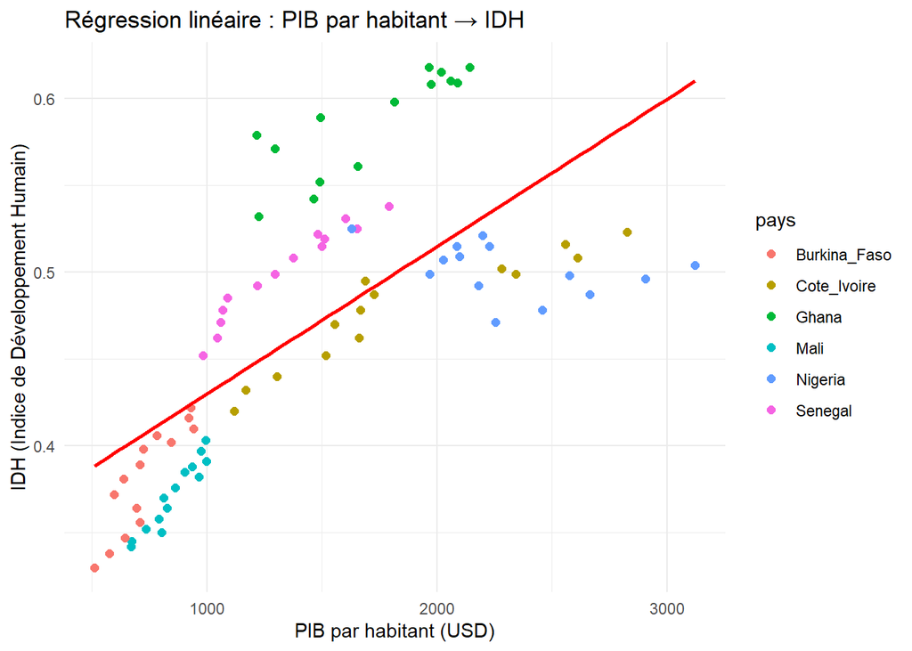

```r
ggplot(data, aes(x = pib_par_habitant_usd, y = idu)) +
  geom_point(aes(color = pays), size = 2) +
  geom_smooth(method = "lm", se = FALSE, color = "red") +
  labs(title = "Régression linéaire : PIB par habitant → IDH",
       x = "PIB par habitant (USD)",
       y = "IDH (Indice de Développement Humain)") +
  theme_minimal()
```

## 11.3 Prédiction

```r
pred <- predict(model, newdata = data.frame(
  pib_par_habitant_usd = 2000,
  taux_alphabetisation = 80,
  taux_pauvrete        = 30
))
cat("IDH prédit (PIB/hab = 2000 USD, alphabétisation = 80%, pauvreté = 30%) :", round(pred, 4))
```

```
## IDH prédit (PIB/hab = 2000 USD, alphabétisation = 80%, pauvreté = 30%) : 0.6198
```

> **Interprétation :** Pour un pays avec un PIB/habitant de 2 000 USD, un taux d’alphabétisation de 80% et un taux de pauvreté de 30%, le modèle prédit un IDH de **0,6198**. Ce niveau correspond à la catégorie « développement humain moyen » selon le PNUD (seuil à 0,55), légèrement supérieur au meilleur IDH observé dans l’échantillon. Cela confirme la cohérence du modèle : améliorer simultanément l’éducation et le revenu individuel permettrait à ces pays de franchir le seuil du développement humain moyen.

# 12 Conclusion Générale

Cette analyse met en évidence plusieurs résultats clés pour le développement économique et humain en Afrique de l’Ouest (2010–2023) :

1. **Fortes inégalités inter-pays** : Le Nigeria domine en PIB absolu, mais ce n’est pas lui qui affiche le meilleur IDH, illustrant le décalage entre richesse nationale et bien-être individuel.
2. **Le revenu par habitant est le meilleur prédicteur de l’IDH** : La corrélation PIB/habitant–IDH (r = 0,70) est bien supérieure à celle du PIB total–IDH (r = 0,27).
3. **L’éducation est le levier n°1** : Le taux d’alphabétisation est le prédicteur le plus puissant de l’IDH dans le modèle de régression (R² global = 0,97).
4. **La croissance ne réduit pas automatiquement la pauvreté** : La corrélation positive entre taux de pauvreté et PIB/habitant souligne l’importance des politiques redistributives.
5. **Des inégalités structurelles confirmées** : Le test de Kruskal-Wallis confirme des différences significatives entre pays (p < 0,001).

**Recommandations de politique publique :** Pour améliorer le développement humain dans la région, les priorités doivent être l’investissement massif en éducation, la croissance inclusive du revenu individuel, le contrôle de l’inflation et la mise en place de mécanismes de redistribution des richesses.